# Deliverable 3: Data Preprocessing

Ariela Grady

10/26/26

# Introduction

This report provides an initial exploration of the FIFA World Ranking dataset. The purpose of this analysis is to understand the structure and quality of the data before performing more advanced analyses later in the semester. The report includes a data dictionary, summary statistics, an assessment of data cleanliness, and a discussion of key findings.

# Data Dimensions

```r
fifa <- read.csv("fifa_ranking.csv")

print(nrow(fifa))
```

```
## [1] 57793
```

```r
print(ncol(fifa))
```

```
## [1] 16
```

### Description

The dataset contains the historical FIFA rankings of national soccer teams. Each row represents a country’s ranking at a specific date, while each column contains information about ranking performance, points earned, or country identification.

# Data Dictionary

```r
data_dictionary <- data.frame(
  Variable = names(fifa),
  Data_Type = sapply(fifa, class)
)

kable(data_dictionary,
      caption = "Data Dictionary")
```

Data Dictionary

|  | Variable | Data_Type |
| --- | --- | --- |
| rank | rank | integer |
| country_full | country_full | character |
| country_abrv | country_abrv | character |
| total_points | total_points | numeric |
| previous_points | previous_points | integer |
| rank_change | rank_change | integer |
| cur_year_avg | cur_year_avg | numeric |
| cur_year_avg_weighted | cur_year_avg_weighted | numeric |
| last_year_avg | last_year_avg | numeric |
| last_year_avg_weighted | last_year_avg_weighted | numeric |
| two_year_ago_avg | two_year_ago_avg | numeric |
| two_year_ago_weighted | two_year_ago_weighted | numeric |
| three_year_ago_avg | three_year_ago_avg | numeric |
| three_year_ago_weighted | three_year_ago_weighted | numeric |
| confederation | confederation | character |
| rank_date | rank_date | character |

### Description

The table above lists every variable contained in the dataset along with its data type. Variables consist of numerical ranking metrics, categorical country identifiers, and date information.

# Summary Statistics

## Overall Summary

```r
summary(fifa)
```

```
##       rank          country_full      country_abrv    total_points
##  Min.   :  1.0   Length   :57793   Length   :57793   Min.   :   0.00
##  1st Qu.: 51.0   N.unique :  216   N.unique :  216   1st Qu.:   0.00
##  Median :101.0   N.blank  :    0   N.blank  :    0   Median :   0.00
##  Mean   :101.6   Min.nchar:    3   Min.nchar:    3   Mean   : 122.07
##  3rd Qu.:152.0   Max.nchar:   29   Max.nchar:    3   3rd Qu.:  92.79
##  Max.   :209.0                                       Max.   :1775.03
##  previous_points   rank_change          cur_year_avg     cur_year_avg_weighted
##  Min.   :   0.0   Min.   :-72.000000   Min.   :   0.00   Min.   :   0.00
##  1st Qu.:  56.0   1st Qu.: -2.000000   1st Qu.:   0.00   1st Qu.:   0.00
##  Median : 272.0   Median :  0.000000   Median :   0.00   Median :   0.00
##  Mean   : 332.3   Mean   : -0.009897   Mean   :  61.80   Mean   :  61.80
##  3rd Qu.: 525.0   3rd Qu.:  1.000000   3rd Qu.:  32.25   3rd Qu.:  32.25
##  Max.   :1920.0   Max.   : 92.000000   Max.   :1158.66   Max.   :1158.66
##  last_year_avg     last_year_avg_weighted two_year_ago_avg
##  Min.   :   0.00   Min.   :  0.00         Min.   :   0.00
##  1st Qu.:   0.00   1st Qu.:  0.00         1st Qu.:   0.00
##  Median :   0.00   Median :  0.00         Median :   0.00
##  Mean   :  61.00   Mean   : 30.50         Mean   :  59.78
##  3rd Qu.:  26.66   3rd Qu.: 13.33         3rd Qu.:  21.50
##  Max.   :1169.57   Max.   :584.79         Max.   :1159.71
##  two_year_ago_weighted three_year_ago_avg three_year_ago_weighted
##  Min.   :  0.00        Min.   :   0.00    Min.   :  0.00
##  1st Qu.:  0.00        1st Qu.:   0.00    1st Qu.:  0.00
##  Median :  0.00        Median :   0.00    Median :  0.00
##  Mean   : 17.93        Mean   :  59.17    Mean   : 11.83
##  3rd Qu.:  6.45        3rd Qu.:  21.25    3rd Qu.:  4.25
##  Max.   :347.91        Max.   :1200.77    Max.   :240.15
##    confederation       rank_date
##  Length   :57793   Length   :57793
##  N.unique :    6   N.unique :  286
##  N.blank  :    0   N.blank  :    0
##  Min.nchar:    3   Min.nchar:   10
##  Max.nchar:    8   Max.nchar:   10
##
```

### Description

The summary statistics provide measures such as minimum values, maximum values, medians, means, and quartiles for numerical variables. These summaries help identify the range and distribution of values present in the dataset.

# Numerical Variable Analysis

## Distribution of FIFA Rank

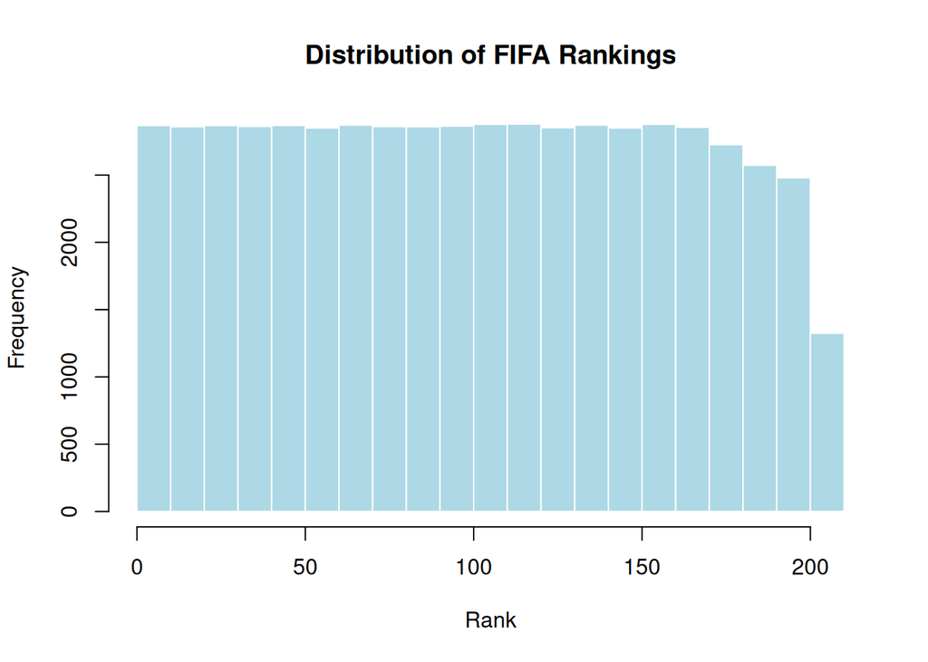

```r
hist(fifa$rank,
     main = "Distribution of FIFA Rankings",
     xlab = "Rank",
     col = "lightblue",
     border = "white")
```

### Description

This histogram shows the distribution of ranking positions within the dataset. The rankings span a large range, reflecting the numerous national teams represented in FIFA’s ranking system.

## Distribution of Total Points

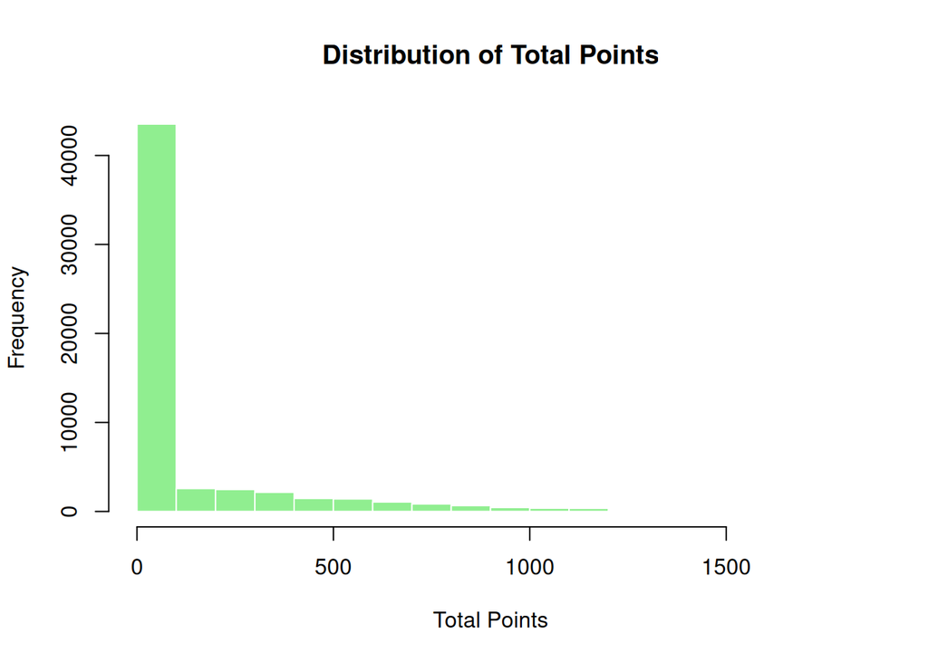

```r
if("total_points" %in% names(fifa)) {

hist(fifa$total_points,
     main = "Distribution of Total Points",
     xlab = "Total Points",
     col = "lightgreen",
     border = "white")

}
```

### Description

The total points variable measures the number of ranking points earned by each national team. This visualization helps identify whether most teams cluster around similar point totals or whether a few countries stand out.

## Distribution of Rank Change

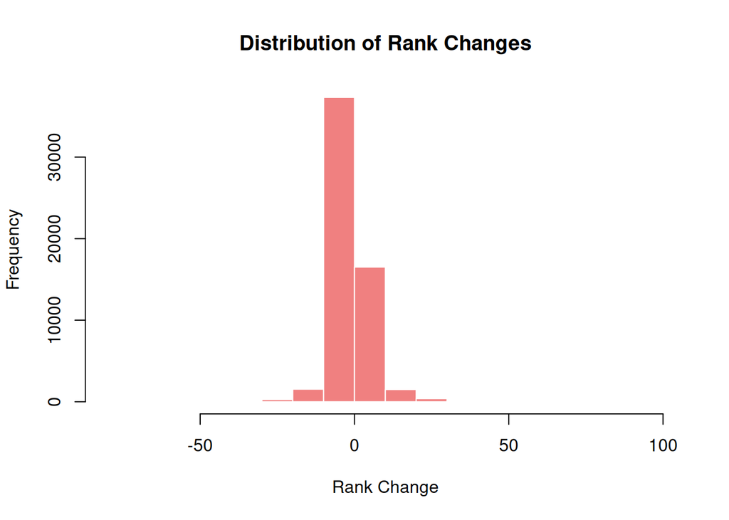

```r
if("rank_change" %in% names(fifa)) {

hist(fifa$rank_change,
     main = "Distribution of Rank Changes",
     xlab = "Rank Change",
     col = "lightcoral",
     border = "white")

}
```

### Description

Rank change measures how much a country’s ranking has improved or worsened between ranking periods. Most values are expected to center near zero because dramatic changes in rankings are relatively uncommon.

# Categorical Variable Analysis

## Confederation Frequency

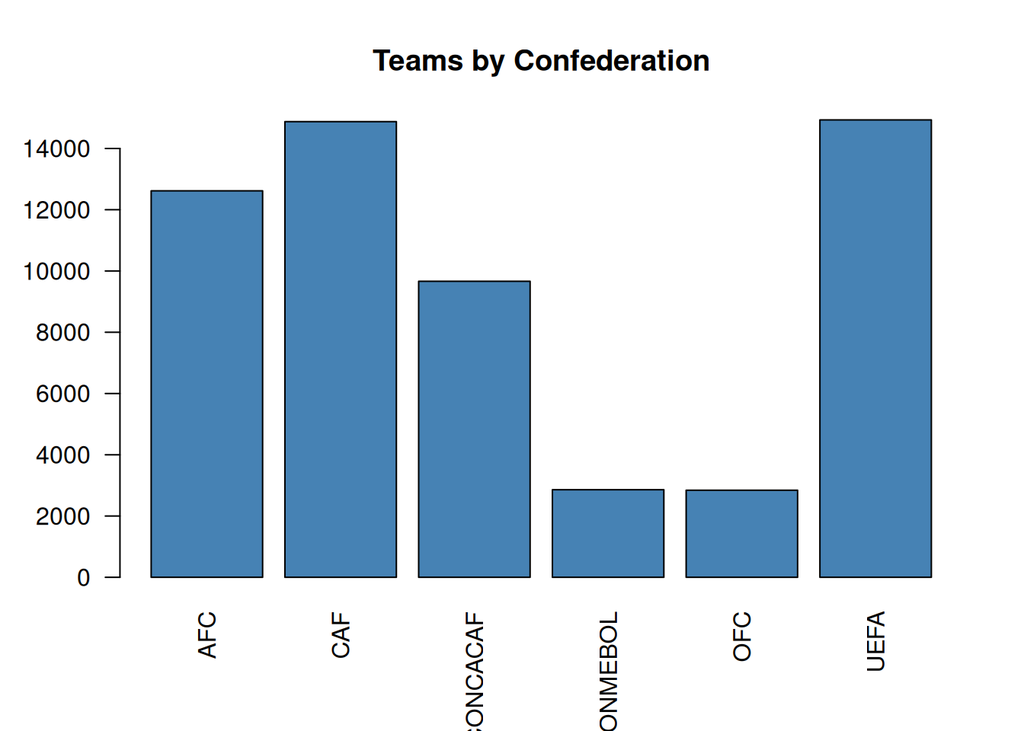

```r
if("confederation" %in% names(fifa)) {

confed_table <- table(fifa$confederation)

kable(as.data.frame(confed_table),
      col.names = c("Confederation", "Frequency"),
      caption = "Frequency of Confederations")

barplot(confed_table,
        col = "steelblue",
        main = "Teams by Confederation",
        las = 2)

}
```

# Time-Based Exploration

## Brazil Ranking Through Time

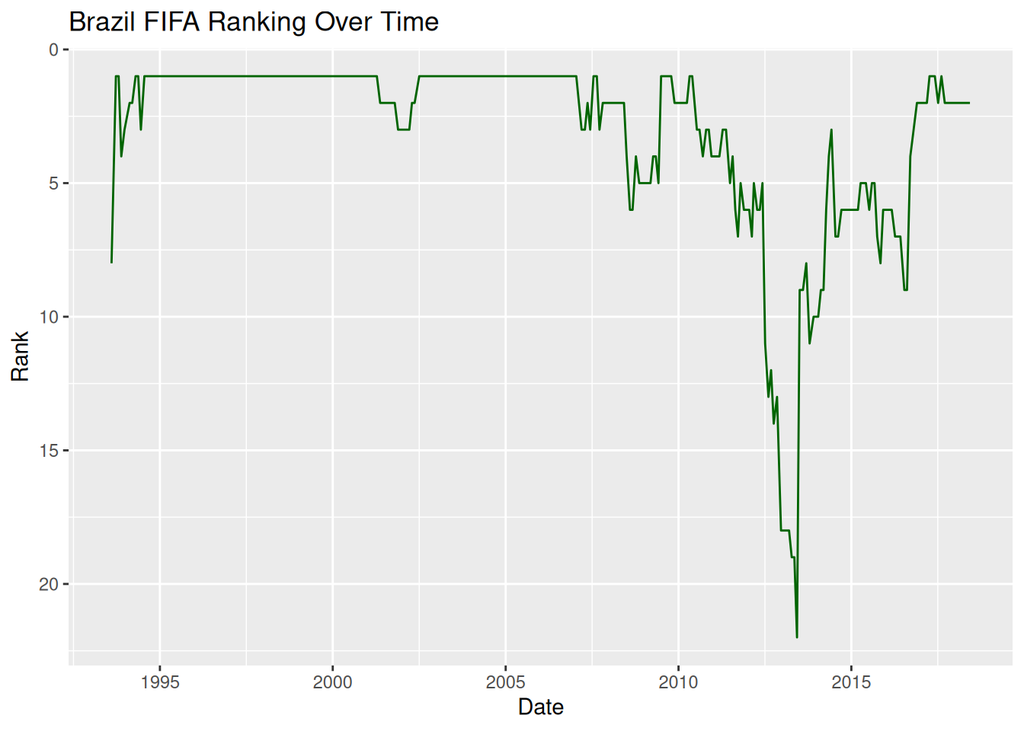

```r
if("country_full" %in% names(fifa) &&
   "rank_date" %in% names(fifa)) {

fifa$rank_date <- as.Date(fifa$rank_date)

brazil <- fifa %>%
  filter(country_full == "Brazil")

if(nrow(brazil) > 0){

ggplot(brazil,
       aes(x = rank_date,
           y = rank)) +
  geom_line(color = "darkgreen") +
  scale_y_reverse() +
  labs(
    title = "Brazil FIFA Ranking Over Time",
    x = "Date",
    y = "Rank"
  )

}

}
```

### Description

This figure tracks Brazil’s ranking across time. Because a lower numerical rank indicates stronger performance, the y-axis is reversed to make improvements appear higher on the graph.

# Data Cleanliness

## Missing Values

```r
missing_values <- colSums(is.na(fifa))

kable(
  data.frame(
    Variable = names(missing_values),
    Missing_Values = missing_values
  ),
  caption = "Missing Values by Variable"
)
```

Missing Values by Variable

|  | Variable | Missing_Values |
| --- | --- | --- |
| rank | rank | 0 |
| country_full | country_full | 0 |
| country_abrv | country_abrv | 0 |
| total_points | total_points | 0 |
| previous_points | previous_points | 0 |
| rank_change | rank_change | 0 |
| cur_year_avg | cur_year_avg | 0 |
| cur_year_avg_weighted | cur_year_avg_weighted | 0 |
| last_year_avg | last_year_avg | 0 |
| last_year_avg_weighted | last_year_avg_weighted | 0 |
| two_year_ago_avg | two_year_ago_avg | 0 |
| two_year_ago_weighted | two_year_ago_weighted | 0 |
| three_year_ago_avg | three_year_ago_avg | 0 |
| three_year_ago_weighted | three_year_ago_weighted | 0 |
| confederation | confederation | 0 |
| rank_date | rank_date | 0 |

### Description

The table above identifies missing values for each variable. Variables with large numbers of missing observations may require cleaning or special handling during future analyses.

## Duplicate Observations

```r
duplicates <- sum(duplicated(fifa))

duplicates
```

```
## [1] 37
```

### Description

This value represents the number of completely duplicated rows in the dataset. Duplicate observations can introduce bias and should be reviewed before further analysis.

## Data Structure

```r
str(fifa)
```

```
## 'data.frame':    57793 obs. of  16 variables:
##  $ rank                   : int  1 2 3 4 5 6 7 8 9 10 ...
##  $ country_full           : chr  "Germany" "Italy" "Switzerland" "Sweden" ...
##  $ country_abrv           : chr  "GER" "ITA" "SUI" "SWE" ...
##  $ total_points           : num  0 0 0 0 0 0 0 0 0 0 ...
##  $ previous_points        : int  57 57 50 55 51 54 52 55 49 51 ...
##  $ rank_change            : int  0 0 9 0 5 0 1 -5 5 -1 ...
##  $ cur_year_avg           : num  0 0 0 0 0 0 0 0 0 0 ...
##  $ cur_year_avg_weighted  : num  0 0 0 0 0 0 0 0 0 0 ...
##  $ last_year_avg          : num  0 0 0 0 0 0 0 0 0 0 ...
##  $ last_year_avg_weighted : num  0 0 0 0 0 0 0 0 0 0 ...
##  $ two_year_ago_avg       : num  0 0 0 0 0 0 0 0 0 0 ...
##  $ two_year_ago_weighted  : num  0 0 0 0 0 0 0 0 0 0 ...
##  $ three_year_ago_avg     : num  0 0 0 0 0 0 0 0 0 0 ...
##  $ three_year_ago_weighted: num  0 0 0 0 0 0 0 0 0 0 ...
##  $ confederation          : chr  "UEFA" "UEFA" "UEFA" "UEFA" ...
##  $ rank_date              : Date, format: "1993-08-08" "1993-08-08" ...
```

### Description

The structure output confirms how each variable was imported. It helps identify whether variables have appropriate data types for analysis.

## Correlation Analysis

```r
numeric_vars <- fifa %>%
  select(where(is.numeric))

if(ncol(numeric_vars) > 1){

cor_matrix <- cor(numeric_vars,
                  use = "pairwise.complete.obs")

round(cor_matrix, 2)

}
```

```
##                          rank total_points previous_points rank_change
## rank                     1.00        -0.34           -0.73       -0.05
## total_points            -0.34         1.00            0.53        0.02
## previous_points         -0.73         0.53            1.00       -0.03
## rank_change             -0.05         0.02           -0.03        1.00
## cur_year_avg            -0.34         0.97            0.52        0.05
## cur_year_avg_weighted   -0.34         0.97            0.52        0.05
## last_year_avg           -0.32         0.93            0.50       -0.02
## last_year_avg_weighted  -0.32         0.93            0.50       -0.02
## two_year_ago_avg        -0.31         0.92            0.48        0.00
## two_year_ago_weighted   -0.31         0.92            0.48        0.00
## three_year_ago_avg      -0.31         0.91            0.48        0.00
## three_year_ago_weighted -0.31         0.91            0.48        0.00
##                         cur_year_avg cur_year_avg_weighted last_year_avg
## rank                           -0.34                 -0.34         -0.32
## total_points                    0.97                  0.97          0.93
## previous_points                 0.52                  0.52          0.50
## rank_change                     0.05                  0.05         -0.02
## cur_year_avg                    1.00                  1.00          0.84
## cur_year_avg_weighted           1.00                  1.00          0.84
## last_year_avg                   0.84                  0.84          1.00
## last_year_avg_weighted          0.84                  0.84          1.00
## two_year_ago_avg                0.85                  0.85          0.84
## two_year_ago_weighted           0.85                  0.85          0.84
## three_year_ago_avg              0.84                  0.84          0.85
## three_year_ago_weighted         0.84                  0.84          0.85
##                         last_year_avg_weighted two_year_ago_avg
## rank                                     -0.32            -0.31
## total_points                              0.93             0.92
## previous_points                           0.50             0.48
## rank_change                              -0.02             0.00
## cur_year_avg                              0.84             0.85
## cur_year_avg_weighted                     0.84             0.85
## last_year_avg                             1.00             0.84
## last_year_avg_weighted                    1.00             0.84
## two_year_ago_avg                          0.84             1.00
## two_year_ago_weighted                     0.84             1.00
## three_year_ago_avg                        0.85             0.84
## three_year_ago_weighted                   0.85             0.84
##                         two_year_ago_weighted three_year_ago_avg
```

[output cut: 10 more lines]

```
## three_year_ago_avg                       0.84               1.00
## three_year_ago_weighted                  0.84               1.00
##                         three_year_ago_weighted
## rank                                      -0.31
## total_points                               0.91
## previous_points                            0.48
## rank_change                                0.00
## cur_year_avg                               0.84
## cur_year_avg_weighted                      0.84
## last_year_avg                              0.85
## last_year_avg_weighted                     0.85
## two_year_ago_avg                           0.84
## two_year_ago_weighted                      0.84
## three_year_ago_avg                         1.00
## three_year_ago_weighted                    1.00
```

### Description

Correlation analysis measures relationships between numerical variables. Strong positive or negative correlations may indicate variables that describe similar patterns or behaviors.

# Data Quality Concerns

# Discussion

The FIFA rankings dataset provides a rich collection of information regarding the historical performance of national soccer teams around the world. The dataset includes both categorical variables, such as country names and confederations, and numerical variables, such as rankings and points. Initial exploration suggests substantial variation among countries, which makes the dataset suitable for studying ranking trends and competitive performance across different regions.

One particularly interesting aspect of the dataset is its time-series structure. Because countries appear repeatedly across many years, it becomes possible to examine how rankings change over time and identify periods of improvement or decline. Future analyses may focus on comparing confederations, identifying the most consistently successful countries, and exploring how ranking points influence ranking position. Additional investigation of missing values and highly correlated variables will also help improve the quality of future analyses.